# Risk Factor Analysis

## Outcome Variable

**Outcome Variable:** wasted

## Predictor Variables

**Intervention Variable:** feducyrs

**Adjustment Set:**

- arm
- W_mage
- meducyrs
- hhwealth_quart
- W_mhtcm
- W_mwtkg
- W_mbmi
- W_gagebrth
- W_birthwt
- W_birthlen
- single
- delta_W_mage
- delta_meducyrs
- delta_hhwealth_quart
- delta_W_mhtcm
- delta_W_mwtkg
- delta_W_mbmi
- delta_W_gagebrth
- delta_W_birthwt
- delta_W_birthlen
- delta_single

## Stratifying Variables

The analysis was stratified on these variable(s):

- agecat
- studyid
- country

## Data Summary

| agecat | studyid | country | feducyrs | wasted | n_cell | n |
| --- | --- | --- | --- | --- | --- | --- |
| Birth | COHORTS | GUATEMALA | High | 0 | 95 | 718 |
| Birth | COHORTS | GUATEMALA | High | 1 | 41 | 718 |
| Birth | COHORTS | GUATEMALA | Low | 0 | 232 | 718 |
| Birth | COHORTS | GUATEMALA | Low | 1 | 79 | 718 |
| Birth | COHORTS | GUATEMALA | Medium | 0 | 210 | 718 |
| Birth | COHORTS | GUATEMALA | Medium | 1 | 61 | 718 |
| Birth | COHORTS | INDIA | High | 0 | 418 | 1291 |
| Birth | COHORTS | INDIA | High | 1 | 89 | 1291 |
| Birth | COHORTS | INDIA | Low | 0 | 359 | 1291 |
| Birth | COHORTS | INDIA | Low | 1 | 55 | 1291 |
| Birth | COHORTS | INDIA | Medium | 0 | 293 | 1291 |
| Birth | COHORTS | INDIA | Medium | 1 | 77 | 1291 |
| Birth | COHORTS | PHILIPPINES | High | 0 | 818 | 2728 |
| Birth | COHORTS | PHILIPPINES | High | 1 | 176 | 2728 |
| Birth | COHORTS | PHILIPPINES | Low | 0 | 673 | 2728 |
| Birth | COHORTS | PHILIPPINES | Low | 1 | 100 | 2728 |
| Birth | COHORTS | PHILIPPINES | Medium | 0 | 826 | 2728 |
| Birth | COHORTS | PHILIPPINES | Medium | 1 | 135 | 2728 |
| Birth | GMS-Nepal | NEPAL | High | 0 | 118 | 640 |
| Birth | GMS-Nepal | NEPAL | High | 1 | 44 | 640 |
| Birth | GMS-Nepal | NEPAL | Low | 0 | 223 | 640 |
| Birth | GMS-Nepal | NEPAL | Low | 1 | 43 | 640 |
| Birth | GMS-Nepal | NEPAL | Medium | 0 | 167 | 640 |
| Birth | GMS-Nepal | NEPAL | Medium | 1 | 45 | 640 |
| Birth | JiVitA-3 | BANGLADESH | High | 0 | 3606 | 17367 |
| Birth | JiVitA-3 | BANGLADESH | High | 1 | 443 | 17367 |
| Birth | JiVitA-3 | BANGLADESH | Low | 0 | 6633 | 17367 |
| Birth | JiVitA-3 | BANGLADESH | Low | 1 | 819 | 17367 |
| Birth | JiVitA-3 | BANGLADESH | Medium | 0 | 5234 | 17367 |
| Birth | JiVitA-3 | BANGLADESH | Medium | 1 | 632 | 17367 |

[output cut: 300 more lines]

The following strata were considered:

- agecat: 24 months, studyid: COHORTS, country: GUATEMALA
- agecat: 24 months, studyid: COHORTS, country: INDIA
- agecat: 24 months, studyid: COHORTS, country: PHILIPPINES
- agecat: 24 months, studyid: GMS-Nepal, country: NEPAL
- agecat: 24 months, studyid: JiVitA-3, country: BANGLADESH
- agecat: 24 months, studyid: JiVitA-4, country: BANGLADESH
- agecat: 24 months, studyid: LCNI-5, country: MALAWI
- agecat: 24 months, studyid: MAL-ED, country: BANGLADESH
- agecat: 24 months, studyid: MAL-ED, country: INDIA
- agecat: 24 months, studyid: MAL-ED, country: NEPAL
- agecat: 24 months, studyid: MAL-ED, country: PERU
- agecat: 24 months, studyid: MAL-ED, country: SOUTH AFRICA
- agecat: 24 months, studyid: MAL-ED, country: TANZANIA, UNITED REPUBLIC OF
- agecat: 24 months, studyid: NIH-Crypto, country: BANGLADESH
- agecat: 24 months, studyid: PROBIT, country: BELARUS
- agecat: 24 months, studyid: PROVIDE, country: BANGLADESH
- agecat: 24 months, studyid: TanzaniaChild2, country: TANZANIA, UNITED REPUBLIC OF
- agecat: 24 months, studyid: ZVITAMBO, country: ZIMBABWE
- agecat: 6 months, studyid: COHORTS, country: GUATEMALA
- agecat: 6 months, studyid: COHORTS, country: INDIA
- agecat: 6 months, studyid: COHORTS, country: PHILIPPINES
- agecat: 6 months, studyid: GMS-Nepal, country: NEPAL
- agecat: 6 months, studyid: JiVitA-3, country: BANGLADESH
- agecat: 6 months, studyid: JiVitA-4, country: BANGLADESH
- agecat: 6 months, studyid: LCNI-5, country: MALAWI
- agecat: 6 months, studyid: MAL-ED, country: BANGLADESH
- agecat: 6 months, studyid: MAL-ED, country: INDIA
- agecat: 6 months, studyid: MAL-ED, country: NEPAL
- agecat: 6 months, studyid: MAL-ED, country: PERU
- agecat: 6 months, studyid: MAL-ED, country: SOUTH AFRICA
- agecat: 6 months, studyid: MAL-ED, country: TANZANIA, UNITED REPUBLIC OF
- agecat: 6 months, studyid: NIH-Crypto, country: BANGLADESH
- agecat: 6 months, studyid: PROBIT, country: BELARUS
- agecat: 6 months, studyid: PROVIDE, country: BANGLADESH
- agecat: 6 months, studyid: SAS-CompFeed, country: INDIA
- agecat: 6 months, studyid: SAS-FoodSuppl, country: INDIA
- agecat: 6 months, studyid: TanzaniaChild2, country: TANZANIA, UNITED REPUBLIC OF
- agecat: 6 months, studyid: ZVITAMBO, country: ZIMBABWE
- agecat: Birth, studyid: COHORTS, country: GUATEMALA
- agecat: Birth, studyid: COHORTS, country: INDIA
- agecat: Birth, studyid: COHORTS, country: PHILIPPINES
- agecat: Birth, studyid: GMS-Nepal, country: NEPAL
- agecat: Birth, studyid: JiVitA-3, country: BANGLADESH
- agecat: Birth, studyid: JiVitA-4, country: BANGLADESH
- agecat: Birth, studyid: MAL-ED, country: BANGLADESH
- agecat: Birth, studyid: MAL-ED, country: INDIA
- agecat: Birth, studyid: MAL-ED, country: NEPAL
- agecat: Birth, studyid: MAL-ED, country: PERU
- agecat: Birth, studyid: MAL-ED, country: SOUTH AFRICA
- agecat: Birth, studyid: MAL-ED, country: TANZANIA, UNITED REPUBLIC OF
- agecat: Birth, studyid: NIH-Crypto, country: BANGLADESH
- agecat: Birth, studyid: PROBIT, country: BELARUS
- agecat: Birth, studyid: PROVIDE, country: BANGLADESH
- agecat: Birth, studyid: SAS-CompFeed, country: INDIA
- agecat: Birth, studyid: ZVITAMBO, country: ZIMBABWE

### Dropped Strata

Some strata were dropped due to rare outcomes:

- agecat: Birth, studyid: MAL-ED, country: BANGLADESH
- agecat: Birth, studyid: MAL-ED, country: INDIA
- agecat: Birth, studyid: MAL-ED, country: NEPAL
- agecat: Birth, studyid: MAL-ED, country: PERU
- agecat: Birth, studyid: MAL-ED, country: SOUTH AFRICA
- agecat: Birth, studyid: MAL-ED, country: TANZANIA, UNITED REPUBLIC OF
- agecat: 6 months, studyid: LCNI-5, country: MALAWI
- agecat: 6 months, studyid: MAL-ED, country: BANGLADESH
- agecat: 6 months, studyid: MAL-ED, country: INDIA
- agecat: 6 months, studyid: MAL-ED, country: NEPAL
- agecat: 6 months, studyid: MAL-ED, country: PERU
- agecat: 6 months, studyid: MAL-ED, country: SOUTH AFRICA
- agecat: 6 months, studyid: MAL-ED, country: TANZANIA, UNITED REPUBLIC OF
- agecat: 24 months, studyid: LCNI-5, country: MALAWI
- agecat: 24 months, studyid: MAL-ED, country: BANGLADESH
- agecat: 24 months, studyid: MAL-ED, country: INDIA
- agecat: 24 months, studyid: MAL-ED, country: NEPAL
- agecat: 24 months, studyid: MAL-ED, country: PERU
- agecat: 24 months, studyid: MAL-ED, country: SOUTH AFRICA
- agecat: 24 months, studyid: MAL-ED, country: TANZANIA, UNITED REPUBLIC OF
- agecat: 24 months, studyid: PROBIT, country: BELARUS
- agecat: 24 months, studyid: TanzaniaChild2, country: TANZANIA, UNITED REPUBLIC OF
- agecat: 24 months, studyid: ZVITAMBO, country: ZIMBABWE

## Methods Detail

We’re interested in the causal parameters $E[Y_a]$ for all values of $a \in \mathcal{A}$. These parameters represent the mean outcome if, possibly contrary to fact, we intervened to set all units to have $A=a$. Under the randomization and positivity assumptions, these are identified by the statistical parameters $\psi_a=E_W[E_{Y|A,W}(Y|A=a,W)]$. In addition, we’re interested in the mean of $Y$, $E[Y]$ under no intervention (the observed mean). We will estimate these parameters by using SuperLearner to fit the relevant likelihood factors – $E_{Y|A,W}(Y|A=a,W)$ and $p(A=a|W)$, and then updating our likelihood fit using a joint TMLE.

For unadjusted analyses ($W=\{\}$), initial likelihoods were estimated using Lrnr_glm to estimate the simple $E(Y|A)$ and Lrnr_mean to estimate $p(A)$. For adjusted analyses, a small library containing Lrnr_glmnet, Lrnr_xgboost, and Lrnr_mean was used.

Having estimated these parameters, we will then use the delta method to estimate relative risks and attributable risks relative to a prespecified baseline level of $A$.

# Results Detail

## Results Plots

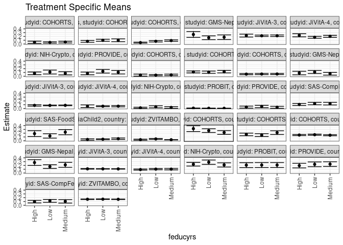

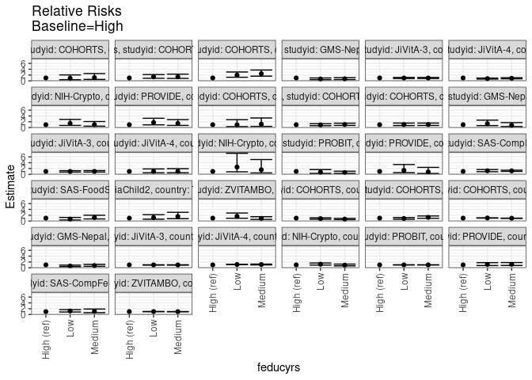

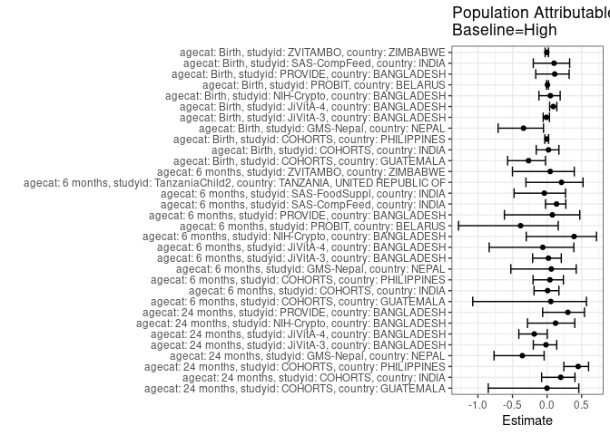

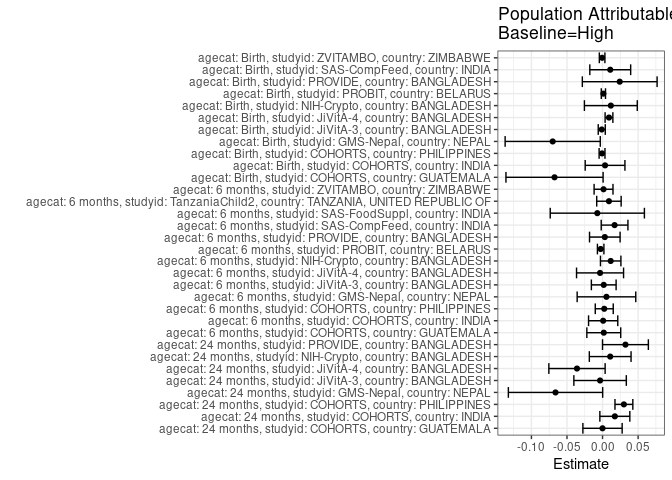

## Results Table

### Parameter: TSM

| agecat | studyid | country | intervention_level | baseline_level | estimate | ci_lower | ci_upper |
| --- | --- | --- | --- | --- | --- | --- | --- |
| Birth | COHORTS | GUATEMALA | High | NA | 0.3196123 | 0.2428970 | 0.3963276 |
| Birth | COHORTS | GUATEMALA | Low | NA | 0.2672349 | 0.2183097 | 0.3161600 |
| Birth | COHORTS | GUATEMALA | Medium | NA | 0.2177582 | 0.1678192 | 0.2676972 |
| Birth | COHORTS | INDIA | High | NA | 0.1676480 | 0.1331729 | 0.2021231 |
| Birth | COHORTS | INDIA | Low | NA | 0.1493390 | 0.1120339 | 0.1866442 |
| Birth | COHORTS | INDIA | Medium | NA | 0.2143211 | 0.1651628 | 0.2634794 |
| Birth | COHORTS | PHILIPPINES | High | NA | 0.1513722 | 0.1373207 | 0.1654238 |
| Birth | COHORTS | PHILIPPINES | Low | NA | 0.1595619 | 0.1452102 | 0.1739135 |
| Birth | COHORTS | PHILIPPINES | Medium | NA | 0.1468301 | 0.1329802 | 0.1606801 |
| Birth | GMS-Nepal | NEPAL | High | NA | 0.2763326 | 0.2004008 | 0.3522643 |
| Birth | GMS-Nepal | NEPAL | Low | NA | 0.1698013 | 0.1209644 | 0.2186382 |
| Birth | GMS-Nepal | NEPAL | Medium | NA | 0.2158343 | 0.1509296 | 0.2807389 |
| Birth | JiVitA-3 | BANGLADESH | High | NA | 0.1101634 | 0.1028980 | 0.1174288 |
| Birth | JiVitA-3 | BANGLADESH | Low | NA | 0.1093735 | 0.1038121 | 0.1149349 |
| Birth | JiVitA-3 | BANGLADESH | Medium | NA | 0.1080974 | 0.1022622 | 0.1139326 |
| Birth | JiVitA-4 | BANGLADESH | High | NA | 0.0908167 | 0.0759767 | 0.1056568 |
| Birth | JiVitA-4 | BANGLADESH | Low | NA | 0.1024668 | 0.0866976 | 0.1182361 |
| Birth | JiVitA-4 | BANGLADESH | Medium | NA | 0.1022195 | 0.0833345 | 0.1211045 |
| Birth | NIH-Crypto | BANGLADESH | High | NA | 0.2316137 | 0.1833467 | 0.2798808 |
| Birth | NIH-Crypto | BANGLADESH | Low | NA | 0.2855412 | 0.2286548 | 0.3424276 |
| Birth | NIH-Crypto | BANGLADESH | Medium | NA | 0.2138622 | 0.1582923 | 0.2694321 |
| Birth | PROBIT | BELARUS | High | NA | 0.2079413 | 0.1424253 | 0.2734573 |
| Birth | PROBIT | BELARUS | Low | NA | 0.2098272 | 0.1438282 | 0.2758261 |
| Birth | PROBIT | BELARUS | Medium | NA | 0.2101920 | 0.1445795 | 0.2758045 |
| Birth | PROVIDE | BANGLADESH | High | NA | 0.1957813 | 0.1346056 | 0.2569570 |
| Birth | PROVIDE | BANGLADESH | Low | NA | 0.2292621 | 0.1671583 | 0.2913658 |
| Birth | PROVIDE | BANGLADESH | Medium | NA | 0.2343117 | 0.1722230 | 0.2964005 |
| Birth | SAS-CompFeed | INDIA | High | NA | 0.0963579 | 0.0623878 | 0.1303280 |
| Birth | SAS-CompFeed | INDIA | Low | NA | 0.1156361 | 0.0771350 | 0.1541373 |
| Birth | SAS-CompFeed | INDIA | Medium | NA | 0.1041317 | 0.0588957 | 0.1493676 |

[output cut: 66 more lines]

### Parameter: E(Y)

| agecat | studyid | country | intervention_level | baseline_level | estimate | ci_lower | ci_upper |
| --- | --- | --- | --- | --- | --- | --- | --- |
| Birth | COHORTS | GUATEMALA | NA | NA | 0.2520891 | 0.2203065 | 0.2838718 |
| Birth | COHORTS | INDIA | NA | NA | 0.1711851 | 0.1506302 | 0.1917400 |
| Birth | COHORTS | PHILIPPINES | NA | NA | 0.1506598 | 0.1372339 | 0.1640858 |
| Birth | GMS-Nepal | NEPAL | NA | NA | 0.2062500 | 0.1748784 | 0.2376216 |
| Birth | JiVitA-3 | BANGLADESH | NA | NA | 0.1090574 | 0.1037994 | 0.1143154 |
| Birth | JiVitA-4 | BANGLADESH | NA | NA | 0.0998709 | 0.0841992 | 0.1155426 |
| Birth | NIH-Crypto | BANGLADESH | NA | NA | 0.2432815 | 0.2116319 | 0.2749310 |
| Birth | PROBIT | BELARUS | NA | NA | 0.2091386 | 0.1437485 | 0.2745287 |
| Birth | PROVIDE | BANGLADESH | NA | NA | 0.2199248 | 0.1846953 | 0.2551543 |
| Birth | SAS-CompFeed | INDIA | NA | NA | 0.1071753 | 0.0763487 | 0.1380019 |
| Birth | ZVITAMBO | ZIMBABWE | NA | NA | 0.1577985 | 0.1514260 | 0.1641709 |
| 6 months | COHORTS | GUATEMALA | NA | NA | 0.0320442 | 0.0205636 | 0.0435248 |
| 6 months | COHORTS | INDIA | NA | NA | 0.1148014 | 0.0980067 | 0.1315962 |
| 6 months | COHORTS | PHILIPPINES | NA | NA | 0.0581577 | 0.0490934 | 0.0672220 |
| 6 months | GMS-Nepal | NEPAL | NA | NA | 0.0905861 | 0.0668565 | 0.1143158 |
| 6 months | JiVitA-3 | BANGLADESH | NA | NA | 0.0845079 | 0.0795688 | 0.0894470 |
| 6 months | JiVitA-4 | BANGLADESH | NA | NA | 0.0567164 | 0.0477001 | 0.0657328 |
| 6 months | NIH-Crypto | BANGLADESH | NA | NA | 0.0293706 | 0.0169860 | 0.0417552 |
| 6 months | PROBIT | BELARUS | NA | NA | 0.0069047 | 0.0051835 | 0.0086259 |
| 6 months | PROVIDE | BANGLADESH | NA | NA | 0.0414594 | 0.0255348 | 0.0573839 |
| 6 months | SAS-CompFeed | INDIA | NA | NA | 0.1239669 | 0.0988748 | 0.1490591 |
| 6 months | SAS-FoodSuppl | INDIA | NA | NA | 0.1815789 | 0.1427684 | 0.2203895 |
| 6 months | TanzaniaChild2 | TANZANIA, UNITED REPUBLIC OF | NA | NA | 0.0431334 | 0.0342652 | 0.0520016 |
| 6 months | ZVITAMBO | ZIMBABWE | NA | NA | 0.0307283 | 0.0270076 | 0.0344489 |
| 24 months | COHORTS | GUATEMALA | NA | NA | 0.0449102 | 0.0320802 | 0.0577401 |
| 24 months | COHORTS | INDIA | NA | NA | 0.0875912 | 0.0726161 | 0.1025664 |
| 24 months | COHORTS | PHILIPPINES | NA | NA | 0.0668392 | 0.0566723 | 0.0770060 |
| 24 months | GMS-Nepal | NEPAL | NA | NA | 0.1851852 | 0.1506144 | 0.2197560 |
| 24 months | JiVitA-3 | BANGLADESH | NA | NA | 0.2187803 | 0.2086815 | 0.2288790 |
| 24 months | JiVitA-4 | BANGLADESH | NA | NA | 0.1938288 | 0.1801571 | 0.2075004 |
| 24 months | NIH-Crypto | BANGLADESH | NA | NA | 0.0875486 | 0.0630908 | 0.1120065 |
| 24 months | PROVIDE | BANGLADESH | NA | NA | 0.1070812 | 0.0818727 | 0.1322897 |

### Parameter: RR

| agecat | studyid | country | intervention_level | baseline_level | estimate | ci_lower | ci_upper |
| --- | --- | --- | --- | --- | --- | --- | --- |
| Birth | COHORTS | GUATEMALA | High | High | 1.0000000 | 1.0000000 | 1.0000000 |
| Birth | COHORTS | GUATEMALA | Low | High | 0.8361218 | 0.6213172 | 1.1251898 |
| Birth | COHORTS | GUATEMALA | Medium | High | 0.6813197 | 0.4911665 | 0.9450901 |
| Birth | COHORTS | INDIA | High | High | 1.0000000 | 1.0000000 | 1.0000000 |
| Birth | COHORTS | INDIA | Low | High | 0.8907892 | 0.6446861 | 1.2308400 |
| Birth | COHORTS | INDIA | Medium | High | 1.2783995 | 0.9396087 | 1.7393465 |
| Birth | COHORTS | PHILIPPINES | High | High | 1.0000000 | 1.0000000 | 1.0000000 |
| Birth | COHORTS | PHILIPPINES | Low | High | 1.0541025 | 1.0062167 | 1.1042673 |
| Birth | COHORTS | PHILIPPINES | Medium | High | 0.9699939 | 0.9269125 | 1.0150776 |
| Birth | GMS-Nepal | NEPAL | High | High | 1.0000000 | 1.0000000 | 1.0000000 |
| Birth | GMS-Nepal | NEPAL | Low | High | 0.6144818 | 0.4129812 | 0.9142979 |
| Birth | GMS-Nepal | NEPAL | Medium | High | 0.7810671 | 0.5193962 | 1.1745674 |
| Birth | JiVitA-3 | BANGLADESH | High | High | 1.0000000 | 1.0000000 | 1.0000000 |
| Birth | JiVitA-3 | BANGLADESH | Low | High | 0.9928302 | 0.9425611 | 1.0457804 |
| Birth | JiVitA-3 | BANGLADESH | Medium | High | 0.9812461 | 0.9315420 | 1.0336023 |
| Birth | JiVitA-4 | BANGLADESH | High | High | 1.0000000 | 1.0000000 | 1.0000000 |
| Birth | JiVitA-4 | BANGLADESH | Low | High | 1.1282811 | 1.0635352 | 1.1969687 |
| Birth | JiVitA-4 | BANGLADESH | Medium | High | 1.1255580 | 0.9903189 | 1.2792656 |
| Birth | NIH-Crypto | BANGLADESH | High | High | 1.0000000 | 1.0000000 | 1.0000000 |
| Birth | NIH-Crypto | BANGLADESH | Low | High | 1.2328338 | 0.9288883 | 1.6362346 |
| Birth | NIH-Crypto | BANGLADESH | Medium | High | 0.9233572 | 0.6667875 | 1.2786512 |
| Birth | PROBIT | BELARUS | High | High | 1.0000000 | 1.0000000 | 1.0000000 |
| Birth | PROBIT | BELARUS | Low | High | 1.0090692 | 0.9858475 | 1.0328380 |
| Birth | PROBIT | BELARUS | Medium | High | 1.0108235 | 0.9959265 | 1.0259435 |
| Birth | PROVIDE | BANGLADESH | High | High | 1.0000000 | 1.0000000 | 1.0000000 |
| Birth | PROVIDE | BANGLADESH | Low | High | 1.1710110 | 0.7748326 | 1.7697589 |
| Birth | PROVIDE | BANGLADESH | Medium | High | 1.1968036 | 0.7942304 | 1.8034298 |
| Birth | SAS-CompFeed | INDIA | High | High | 1.0000000 | 1.0000000 | 1.0000000 |
| Birth | SAS-CompFeed | INDIA | Low | High | 1.2000693 | 0.8660390 | 1.6629348 |
| Birth | SAS-CompFeed | INDIA | Medium | High | 1.0806762 | 0.6239201 | 1.8718118 |

[output cut: 66 more lines]

### Parameter: PAR

| agecat | studyid | country | intervention_level | baseline_level | estimate | ci_lower | ci_upper |
| --- | --- | --- | --- | --- | --- | --- | --- |
| Birth | COHORTS | GUATEMALA | High | NA | -0.0675232 | -0.1358246 | 0.0007782 |
| Birth | COHORTS | INDIA | High | NA | 0.0035371 | -0.0244062 | 0.0314804 |
| Birth | COHORTS | PHILIPPINES | High | NA | -0.0007124 | -0.0048291 | 0.0034043 |
| Birth | GMS-Nepal | NEPAL | High | NA | -0.0700826 | -0.1369751 | -0.0031901 |
| Birth | JiVitA-3 | BANGLADESH | High | NA | -0.0011060 | -0.0060517 | 0.0038398 |
| Birth | JiVitA-4 | BANGLADESH | High | NA | 0.0090541 | 0.0035966 | 0.0145117 |
| Birth | NIH-Crypto | BANGLADESH | High | NA | 0.0116678 | -0.0255047 | 0.0488402 |
| Birth | PROBIT | BELARUS | High | NA | 0.0011973 | -0.0017639 | 0.0041584 |
| Birth | PROVIDE | BANGLADESH | High | NA | 0.0241435 | -0.0284223 | 0.0767093 |
| Birth | SAS-CompFeed | INDIA | High | NA | 0.0108174 | -0.0179029 | 0.0395378 |
| Birth | ZVITAMBO | ZIMBABWE | High | NA | -0.0006019 | -0.0045213 | 0.0033175 |
| 6 months | COHORTS | GUATEMALA | High | NA | 0.0017412 | -0.0220695 | 0.0255519 |
| 6 months | COHORTS | INDIA | High | NA | 0.0008708 | -0.0196629 | 0.0214046 |
| 6 months | COHORTS | PHILIPPINES | High | NA | 0.0024044 | -0.0102283 | 0.0150370 |
| 6 months | GMS-Nepal | NEPAL | High | NA | 0.0054970 | -0.0357044 | 0.0466985 |
| 6 months | JiVitA-3 | BANGLADESH | High | NA | 0.0016811 | -0.0157031 | 0.0190652 |
| 6 months | JiVitA-4 | BANGLADESH | High | NA | -0.0035038 | -0.0365624 | 0.0295548 |
| 6 months | NIH-Crypto | BANGLADESH | High | NA | 0.0114495 | -0.0029263 | 0.0258253 |
| 6 months | PROBIT | BELARUS | High | NA | -0.0026445 | -0.0072083 | 0.0019193 |
| 6 months | PROVIDE | BANGLADESH | High | NA | 0.0031819 | -0.0183012 | 0.0246649 |
| 6 months | SAS-CompFeed | INDIA | High | NA | 0.0169112 | -0.0018697 | 0.0356921 |
| 6 months | SAS-FoodSuppl | INDIA | High | NA | -0.0073468 | -0.0735553 | 0.0588618 |
| 6 months | TanzaniaChild2 | TANZANIA, UNITED REPUBLIC OF | High | NA | 0.0089838 | -0.0081948 | 0.0261623 |
| 6 months | ZVITAMBO | ZIMBABWE | High | NA | 0.0014053 | -0.0118711 | 0.0146816 |
| 24 months | COHORTS | GUATEMALA | High | NA | -0.0000336 | -0.0276458 | 0.0275785 |
| 24 months | COHORTS | INDIA | High | NA | 0.0172901 | -0.0037674 | 0.0383477 |
| 24 months | COHORTS | PHILIPPINES | High | NA | 0.0300290 | 0.0174721 | 0.0425858 |
| 24 months | GMS-Nepal | NEPAL | High | NA | -0.0661301 | -0.1324357 | 0.0001755 |
| 24 months | JiVitA-3 | BANGLADESH | High | NA | -0.0034541 | -0.0403325 | 0.0334243 |
| 24 months | JiVitA-4 | BANGLADESH | High | NA | -0.0359287 | -0.0754979 | 0.0036405 |
| 24 months | NIH-Crypto | BANGLADESH | High | NA | 0.0107547 | -0.0185788 | 0.0400882 |
| 24 months | PROVIDE | BANGLADESH | High | NA | 0.0322051 | -0.0000168 | 0.0644270 |

### Parameter: PAF

| agecat | studyid | country | intervention_level | baseline_level | estimate | ci_lower | ci_upper |
| --- | --- | --- | --- | --- | --- | --- | --- |
| Birth | COHORTS | GUATEMALA | High | NA | -0.2678544 | -0.5705064 | -0.0235265 |
| Birth | COHORTS | INDIA | High | NA | 0.0206625 | -0.1569485 | 0.1710073 |
| Birth | COHORTS | PHILIPPINES | High | NA | -0.0047286 | -0.0324304 | 0.0222299 |
| Birth | GMS-Nepal | NEPAL | High | NA | -0.3397942 | -0.7071780 | -0.0514712 |
| Birth | JiVitA-3 | BANGLADESH | High | NA | -0.0101412 | -0.0565209 | 0.0342026 |
| Birth | JiVitA-4 | BANGLADESH | High | NA | 0.0906582 | 0.0373139 | 0.1410466 |
| Birth | NIH-Crypto | BANGLADESH | High | NA | 0.0479599 | -0.1177629 | 0.1891121 |
| Birth | PROBIT | BELARUS | High | NA | 0.0057247 | -0.0086855 | 0.0199291 |
| Birth | PROVIDE | BANGLADESH | High | NA | 0.1097808 | -0.1636182 | 0.3189431 |
| Birth | SAS-CompFeed | INDIA | High | NA | 0.1009320 | -0.1995245 | 0.3261303 |
| Birth | ZVITAMBO | ZIMBABWE | High | NA | -0.0038143 | -0.0289633 | 0.0207201 |
| 6 months | COHORTS | GUATEMALA | High | NA | 0.0543365 | -1.0743176 | 0.5688801 |
| 6 months | COHORTS | INDIA | High | NA | 0.0075856 | -0.1883678 | 0.1712276 |
| 6 months | COHORTS | PHILIPPINES | High | NA | 0.0413425 | -0.2023486 | 0.2356425 |
| 6 months | GMS-Nepal | NEPAL | High | NA | 0.0606828 | -0.5240993 | 0.4210897 |
| 6 months | JiVitA-3 | BANGLADESH | High | NA | 0.0198924 | -0.2090662 | 0.2054936 |
| 6 months | JiVitA-4 | BANGLADESH | High | NA | -0.0617775 | -0.8369469 | 0.3862798 |
| 6 months | NIH-Crypto | BANGLADESH | High | NA | 0.3898276 | -0.3012672 | 0.7138863 |
| 6 months | PROBIT | BELARUS | High | NA | -0.3830004 | -1.2799846 | 0.1610952 |
| 6 months | PROVIDE | BANGLADESH | High | NA | 0.0767464 | -0.6169746 | 0.4728444 |
| 6 months | SAS-CompFeed | INDIA | High | NA | 0.1364172 | -0.0229592 | 0.2709629 |
| 6 months | SAS-FoodSuppl | INDIA | High | NA | -0.0404605 | -0.4770086 | 0.2670604 |
| 6 months | TanzaniaChild2 | TANZANIA, UNITED REPUBLIC OF | High | NA | 0.2082793 | -0.3055675 | 0.5198856 |
| 6 months | ZVITAMBO | ZIMBABWE | High | NA | 0.0457326 | -0.5006715 | 0.3931875 |
| 24 months | COHORTS | GUATEMALA | High | NA | -0.0007491 | -0.8498780 | 0.4586137 |
| 24 months | COHORTS | INDIA | High | NA | 0.1973958 | -0.0790924 | 0.4030414 |
| 24 months | COHORTS | PHILIPPINES | High | NA | 0.4492719 | 0.2423875 | 0.5996616 |
| 24 months | GMS-Nepal | NEPAL | High | NA | -0.3571023 | -0.7665192 | -0.0425739 |
| 24 months | JiVitA-3 | BANGLADESH | High | NA | -0.0157879 | -0.1991280 | 0.1395205 |
| 24 months | JiVitA-4 | BANGLADESH | High | NA | -0.1853632 | -0.4082244 | 0.0022286 |
| 24 months | NIH-Crypto | BANGLADESH | High | NA | 0.1228422 | -0.2830233 | 0.4003181 |
| 24 months | PROVIDE | BANGLADESH | High | NA | 0.3007542 | -0.0638850 | 0.5404159 |